```r
options(repos = c(CRAN = "https://cloud.r-project.org"))
```

### Project Motivation:

Credit risk assessment has become an increasingly critical part of the loan application process. As the demand for loan products increases, lenders need to be able to quickly and accurately determine the likelihood of a loan defaulting. In the past, credit risk assessment was a labor-intensive process that required lenders to manually assess each application. This process could be very time-consuming, as lenders had to analyze a variety of data points and review multiple documents. Manual credit risk assessment was also susceptible to human error, which could lead to inaccuracies in the assessment. Traditional methods of assessing credit risk can be inaccurate and may not take into account the full range of factors that can affect a borrower’s ability to repay a loan. Moreover, they can be prone to human bias, which can lead to unfair lending practices. In recent years, advances in technology have enabled lenders to use more accurate and efficient methods of assessing credit risk.

### Data Mining Task:

Four methods we will explore are decision trees to classify and K-means, k-medoids and elbow methods to create clusters of the dataset. These methods are more accurate and efficient than traditional methods. They are able to take into account more factors in assessing credit risk, and are less prone to human bias. Additionally, they are able to process large amounts of data quickly, making them ideal for large-scale lending operations. By applying these algorithms to the credit risk dataset, we aim to develop a robust and accurate model. This can help financial institutions make more informed lending decisions.

Our primary goal is to classify customers as either good or bad credit risks. We aim to assist financial institutions in making informed decisions regarding loan approvals based on an analysis of customers’ payment behavior and other relevant attributes, such as age, income, loan amount, and employment status. By utilizing this dataset, we will build predictive models to assess customers’ creditworthiness and use these models as tools for risk assessment and decision-making.

We also intend to construct clusters for the dataset to understand our dataset better by excluding our class label (the class attribute) then applying the clustring algorithms on the dataset to recognize any patterns or trends between customers which will help to group them into subsets or (clusters) which make it easier to make decisions regarding one group. Four methods we will explore are decision trees to classify and K-means, k-medoids and elbow methods to create clusters of the dataset. These methods are more accurate and efficient than traditional methods. They are able to take into account more factors in assessing credit risk, and are less prone to human bias. Additionally, they are able to process large amounts of data quickly, making them ideal for large-scale lending operations. By applying these algorithms to the credit risk dataset, we aim to develop a robust and accurate model. This can help financial institutions make more informed lending decisions.

### source

The dataset was sourced from the kaggle website in this URL: https://www.kaggle.com/datasets/ppb00x/credit-risk-customers

## Attribute description

[output not shown]

## Summary of the dataset

```r
setwd("C:/Users/jory0/OneDrive/Desktop/DataMining Phase 3")
```

```r
dataset <- read.csv("credit_customers.csv")
```

```r
nrow(dataset)
```

```
## [1] 1000
```

The output is 1000, which is the number of rows

```r
ncol(dataset)
```

```
## [1] 21
```

The output is 21 , which is the number of columns

```r
summary(dataset)
```

```
##  checking_status       duration    credit_history       purpose
##  Length:1000        Min.   : 4.0   Length:1000        Length:1000
##  Class :character   1st Qu.:12.0   Class :character   Class :character
##  Mode  :character   Median :18.0   Mode  :character   Mode  :character
##                     Mean   :20.9
##                     3rd Qu.:24.0
##                     Max.   :72.0
##  credit_amount   savings_status      employment        installment_commitment
##  Min.   :  250   Length:1000        Length:1000        Min.   :1.000
##  1st Qu.: 1366   Class :character   Class :character   1st Qu.:2.000
##  Median : 2320   Mode  :character   Mode  :character   Median :3.000
##  Mean   : 3271                                         Mean   :2.973
##  3rd Qu.: 3972                                         3rd Qu.:4.000
##  Max.   :18424                                         Max.   :4.000
##  personal_status    other_parties      residence_since property_magnitude
##  Length:1000        Length:1000        Min.   :1.000   Length:1000
##  Class :character   Class :character   1st Qu.:2.000   Class :character
##  Mode  :character   Mode  :character   Median :3.000   Mode  :character
##                                        Mean   :2.845
##                                        3rd Qu.:4.000
##                                        Max.   :4.000
##       age        other_payment_plans   housing          existing_credits
##  Min.   :19.00   Length:1000         Length:1000        Min.   :1.000
##  1st Qu.:27.00   Class :character    Class :character   1st Qu.:1.000
##  Median :33.00   Mode  :character    Mode  :character   Median :1.000
##  Mean   :35.55                                          Mean   :1.407
##  3rd Qu.:42.00                                          3rd Qu.:2.000
##  Max.   :75.00                                          Max.   :4.000
##      job            num_dependents  own_telephone      foreign_worker
##  Length:1000        Min.   :1.000   Length:1000        Length:1000
##  Class :character   1st Qu.:1.000   Class :character   Class :character
##  Mode  :character   Median :1.000   Mode  :character   Mode  :character
##                     Mean   :1.155
##                     3rd Qu.:1.000
##                     Max.   :2.000
##     class
##  Length:1000
##  Class :character
##  Mode  :character
##
##
##
```

This summary provides an initial understanding of the data’s structure and characteristics. the min and max in different catagories would help us know the range of the attributes, therefore help us in dealing with the outliers. the mean and median gave us insights that will be helpful during the preproccesing part.

now we want to calculate the variance for the numeric attributes to learn about the spread of the data and how close they are from the mean.

```r
var_duration <- var(dataset$duration)
```

```r
var_age <- var(dataset$age)
```

```r
var_amount <- var(dataset$credit_amount)
```

```r
print(var_duration)
```

```
## [1] 145.415
```

A variance of 145.415 suggests that the data points in the “duration” attribute have some degree of variability. Data points are not tightly clustered around the mean, and there are variations in the durations.

```r
print(var_age)
```

```
## [1] 129.4013
```

129.4013 for the “age” attribute indicates that there is variability in the ages of individuals represented in the dataset. The ages are not highly consistent, and there are differences among individuals.

```r
print(var_amount)
```

```
## [1] 7967843
```

A very high variance of 7,967,843 for the “credit_amount” attribute suggests a significant spread or variability in the credit amounts requested by individuals in the dataset. Some requests may be substantially higher or lower than the mean credit amount, indicating a wide range of credit requests.

we got a closer look at our data using these statical mearues: 1- The length 2- Class type 3- Central tendancy (mode, mean and median) of each attribute with the Q1 and Q3 4- Variance now that we have a deeper insights, we want want to explore and visualize the data further using graphs.

## Graphs

1- We created a bar chart for the class label to know if our dataset is balanced or imbalanced

```r
library(ggplot2)
```

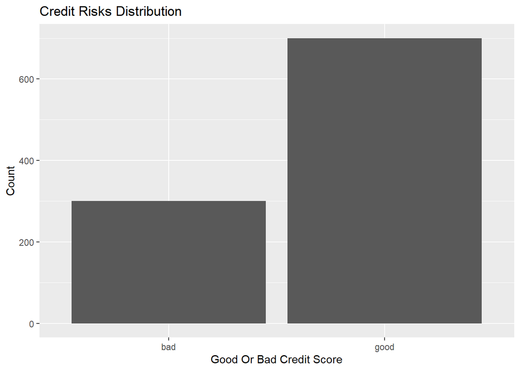

```r
ggplot(dataset, aes(x = class)) +
  geom_bar() +
  labs(x = "Good Or Bad Credit Score", y = "Count") +
  ggtitle("Credit Risks Distribution")
```

From this bar chart we can see that we do not have an balanced dataset, with 70% ‘good’ and 30% ‘bad’ labeled records this dataset is acceptable as it is and we do not need to take further actions regarding this matter.

2-

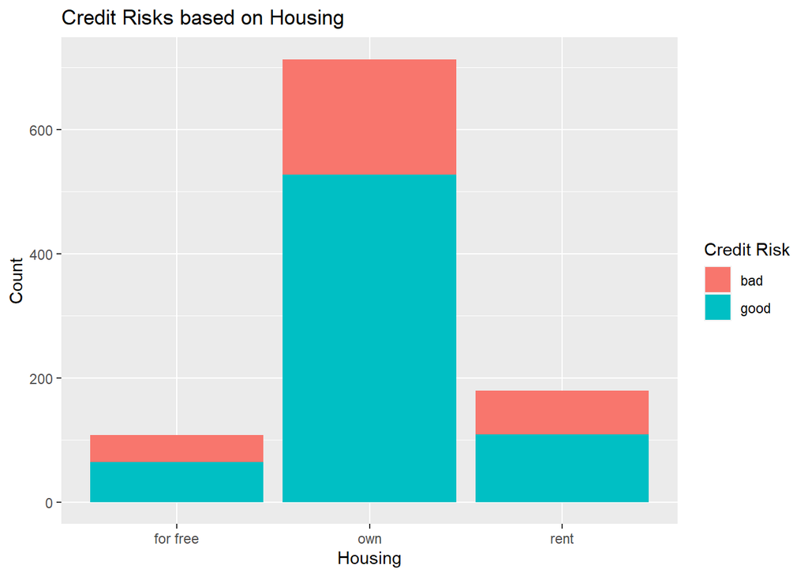

```r
ggplot(dataset, aes(x = housing, fill = class)) +
  geom_bar() +
  labs(
    x = "Housing",
    y = "Count",
    title = "Credit Risks based on Housing",
    fill = "Credit Risk"
  )
```

```r
forfree_bad_count <- nrow (subset(dataset,housing == "for free" & class == "bad"))
```

using this function, we discovered that more than 40% of customers who live in their houses for free have bad credits.

3-

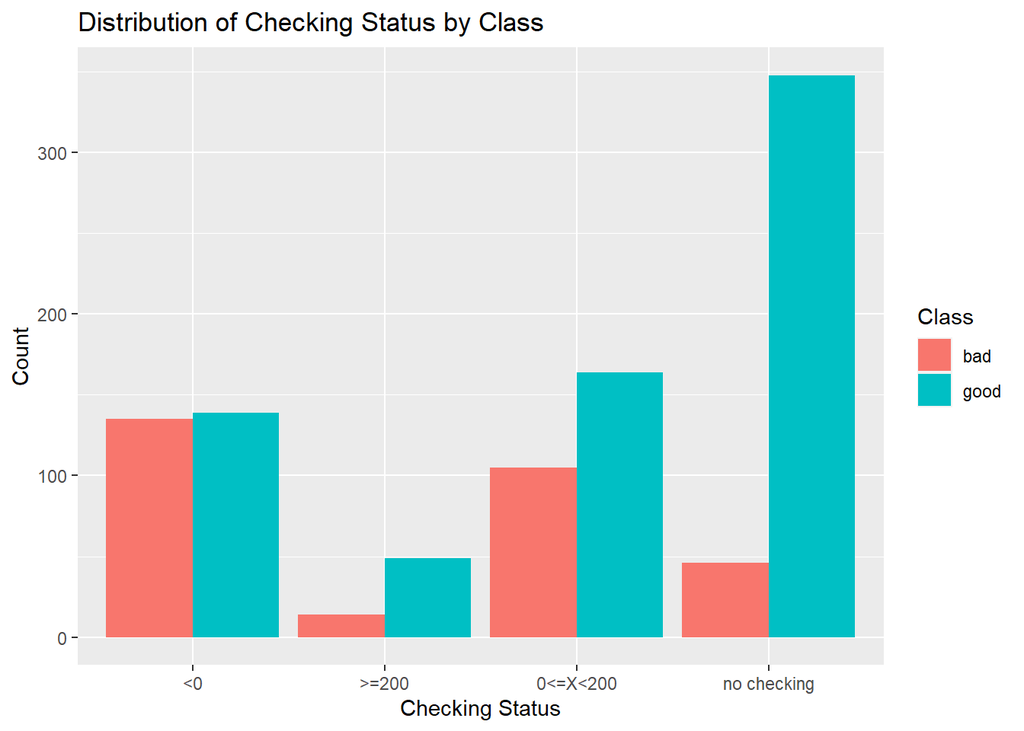

```r
ggplot(dataset, aes(x = checking_status, fill = class)) +
  geom_bar(position = "dodge", stat = "count") +
  labs(title = "Distribution of Checking Status by Class",
       x = "Checking Status",
       y = "Count",
       fill = "Class")
```

this graphs showed us how different checking status is distributed with our class atrribute most costumers that have no checking status is considered having good credit risks meaning having no checking status increases the chances of getting good credit risks

4-

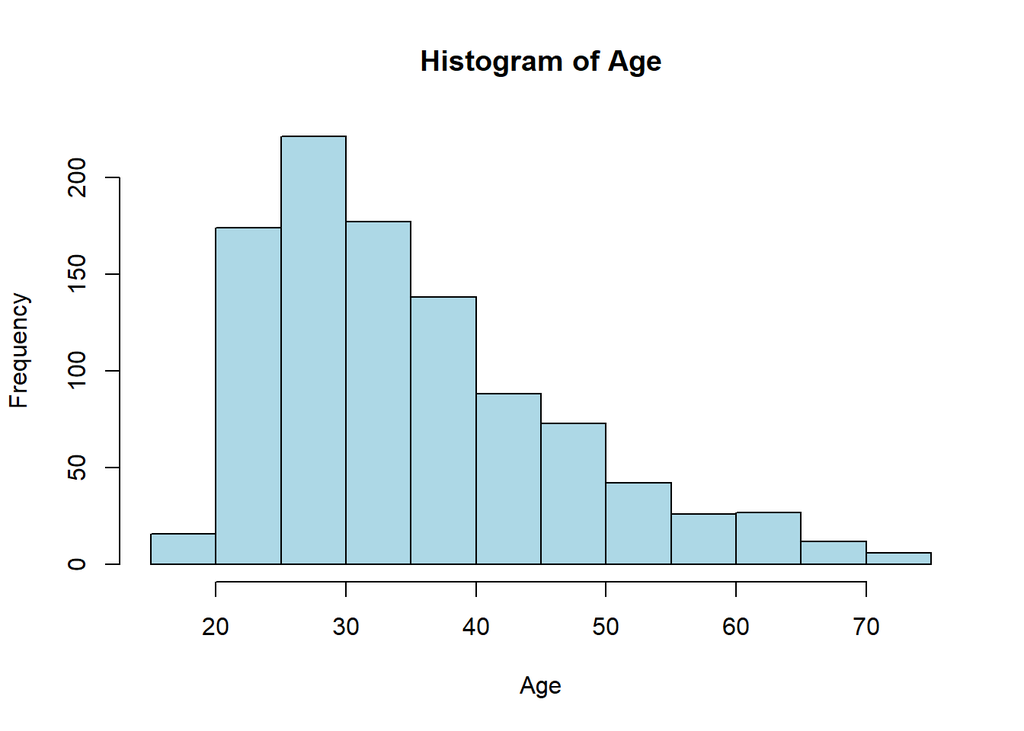

```r
hist(dataset$age, main = "Histogram of Age", xlab = "Age", ylab = "Frequency", col = "lightblue")
```

We created a histogram for the “Age” variable to show the age groups for our sample of customers to give a better understanding for our overall variables values and results.  
most of the customers age lies between (20 - 50) some customers being a bit older there is some outliers in the age 70 that we will study in the outliers section.

5-

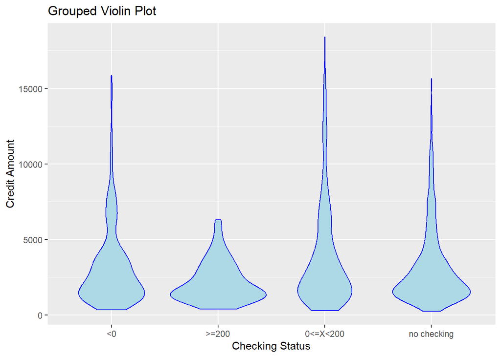

```r
# Create a grouped violin plot with 'checking_status' on the x-axis and 'credit_amount' on the y-axis
ggplot(dataset, aes(x = checking_status, y = credit_amount)) +
  geom_violin(fill = "lightblue", color = "blue") +
  labs(x = "Checking Status", y = "Credit Amount", title = "Grouped Violin Plot")
```

The graph illustrates how the credit amounts are distributed within different categories of checking status. Each violin represents a category of checking status, and its width indicates the density of data points. Also whither there are variations in credit amounts based on checking status which is based on the graph, the checking status varies in the credit amount.

## Outliers

First we find the range of each one of the attributes which is collected in the statical measures we did in the first step using the “summary()” function, using the Min and Max to find the range. this would help us in finding if the outliers detected fall in the range or not

credit_amount range: [250 , 18424 ]

duration range: [4.0 ,72.0]

Age range [19.00 , 75.00]

```r
library(outliers)
```

```r
OutAge <- outlier(dataset$age, logical = TRUE)
OutDuration <- outlier(dataset$duration, logical = TRUE)
Outamount <- outlier(dataset$credit_amount, logical = TRUE)
```

We created a variable “OutAge” , “OutDuration” and “Outamount” to store the result of finding the outliers in the dataset , logical true which specifies the outliers with true .

```r
sum(OutAge)
```

```
## [1] 2
```

```r
sum(OutDuration)
```

```
## [1] 1
```

```r
sum(Outamount)
```

```
## [1] 1
```

```r
Find_outlierAge <- which(OutAge == TRUE, arr.ind = TRUE)
Find_outlierDuration <- which(OutDuration == TRUE, arr.ind = TRUE)
Find_outlierAmount <- which(Outamount == TRUE, arr.ind = TRUE)
```

```r
outlierRowsAge <- dataset[Find_outlierAge, ]
outlierRowsDuration <- dataset[Find_outlierDuration, ]
outlierRowsAmount <- dataset[Find_outlierAmount, ]
```

```r
print(outlierRowsAge)
```

```
##     checking_status duration                 credit_history  purpose
## 331              <0       24 critical/other existing credit used car
## 537              <0        6                  existing paid  new car
##     credit_amount   savings_status employment installment_commitment
## 331          6615             <100 unemployed                      2
## 537          1374 no known savings unemployed                      4
##        personal_status other_parties residence_since property_magnitude age
## 331        male single          none               4  no known property  75
## 537 female div/dep/mar          none               3     life insurance  75
##     other_payment_plans  housing existing_credits                       job
## 331                none for free                2 high qualif/self emp/mgmt
## 537                none      own                1 high qualif/self emp/mgmt
##     num_dependents own_telephone foreign_worker class
## 331              1           yes            yes  good
## 537              1           yes            yes  good
```

```r
print(outlierRowsDuration)
```

```
##     checking_status duration credit_history  purpose credit_amount
## 678        0<=X<200       72  existing paid radio/tv          5595
##     savings_status employment installment_commitment personal_status
## 678     100<=X<500     1<=X<4                      2    male mar/wid
##     other_parties residence_since property_magnitude age other_payment_plans
## 678          none               2                car  24                none
##     housing existing_credits     job num_dependents own_telephone
## 678     own                1 skilled              1          none
##     foreign_worker class
## 678            yes   bad
```

```r
print(outlierRowsAmount)
```

```
##     checking_status duration      credit_history purpose credit_amount
## 916        0<=X<200       48 no credits/all paid   other         18424
##     savings_status employment installment_commitment    personal_status
## 916           <100     1<=X<4                      1 female div/dep/mar
##     other_parties residence_since property_magnitude age other_payment_plans
## 916          none               2     life insurance  32                bank
##     housing existing_credits                       job num_dependents
## 916     own                1 high qualif/self emp/mgmt              1
##     own_telephone foreign_worker class
## 916           yes             no   bad
```

to find the exact row which the outliers are in.

```r
Find_outlierAge <- which(OutAge == TRUE, arr.ind = TRUE)
Find_outlierDuration <- which(OutDuration == TRUE, arr.ind = TRUE)
Find_outlierAmount <- which(Outamount == TRUE, arr.ind = TRUE)
```

Then we find the exact values of the outliers and study them.

```r
cat("Outliers in credit_amount:", Find_outlierAmount, "\n")
```

```
## Outliers in credit_amount: 916
```

```r
cat("Outliers in duration:", Find_outlierDuration, "\n")
```

```
## Outliers in duration: 678
```

```r
cat("Outliers in age:", Find_outlierAge, "\n")
```

```
## Outliers in age: 331 537
```

```r
dataset <- dataset[-Find_outlierAge, ]
dataset <- dataset[!(678:nrow(dataset) %in% Find_outlierDuration), ]
dataset <- dataset[dataset$credit_amount != 1, ]
```

## Checking for Missing Values

```r
total_missing_values <- sum(is.na(dataset))
print(total_missing_values)
```

```
## [1] 0
```

our dataset has not missing values so no need for filling or deleting any rows in that sense.

## Data Conversion (Encoding categorical data)

To prepare the data for analysis, we need to convert certain categorical attributes into numerical values.

Let’s take a closer look at how this is done for specific attributes:

Encoding “checking_status”

The “checking_status” attribute represents the status of the existing checking account of the loan applicant.

```r
dataset$checking_status <- factor(dataset$checking_status, levels = c("no checking","<0", ">=200", "0<=X<200"), labels = c(1, 2, 3, 4))
```

We’ve encoded it as follows: - “no checking” is labeled as 1. - “<0” is labeled as 2. - “>=200” is labeled as 3. - “0<=X<200” is labeled as 4.

```r
dataset$class <- factor(dataset$class, levels = c("bad", "good"), labels = c(0, 1))
```

Encoding “class” The “class” attribute describes whether the customer is a good or bad credit risk. We’ve encoded it as follows:

“bad” is labeled as 0. “good” is labeled as 1

```r
dataset$housing = factor(dataset$housing,levels = c("own","for free", "rent"), labels = c(1, 2, 3))
```

Encoding “housing” The “housing” attribute represents the housing situation of the applicants. We’ve encoded it as follows:

“own” is labeled as 1. “for free” is labeled as 2. “rent” is labeled as 3.

```r
dataset$foreign_worker <- factor(dataset$foreign_worker, levels = c("no", "yes"), labels = c(0, 1))
```

Encoding “foreign_worker” The “foreign_worker” attribute represents whether the loan applicant is a foreign worker or not. We’ve encoded it as follows:

“no” is labeled as 0. “yes” is labeled as 1.

```r
dataset$credit_history = factor(dataset$credit_history,levels = c("no credits/all paid","all paid", "existing paid", "delayed previously", "critical/other existing credit"), labels = c(1, 2, 3, 4, 5))
```

Encoding “credit_history” The “credit_history” attribute represents the credit history for the lone applicant. We’ve encoded it as follows (going from best case to worst) :

“no credits/all paid” is labeled as 1. “all paid” is labeled as 2. “existing paid” is labeled as 3. “delayed previously” is labeled as 4. “critical/other existing credit” is labeled as 5.

```r
 dataset$savings_status <- factor(dataset$savings_status, levels = c('no known savings', '<100', '100<=X<500', '500<=X<1000', '>=1000'), labels = c(1, 2, 3, 4, 5))
```

Encoding “savings_status” The “savings_status” attribute represents the status of the savings account or bond of the loan applicant. We’ve encoded it as follows (going from least to greatest) :

“no known savings” is labeled as 1. “<100” is labeled as 2. “100<=X<500” is labeled as 3. “500<=X<1000” is labeled as 4. “>=1000” is labeled as 5.

```r
dataset$employment <- factor(dataset$employment, levels = c('unemployed', '<1', '1<=X<4', '4<=X<7', '>=7'), labels = c(1, 2, 3, 4, 5))
```

Encoding “employment” The “empolyment” attribute represents the current employment status of the loan applicant in number of years.

We’ve encoded it as follows (going from least to greatest) :

“unemployed” is labeled as 1. “<1” is labeled as 2. “1<=X<4” is labeled as 3. “4<=X<7” is labeled as 4. “>=7” is labeled as 5.

```r
dataset$other_parties <- factor(dataset$other_parties, levels = c('none', 'guarantor', 'co applicant'), labels = c(1, 2, 3))
```

Encoding “other_parties” The “other_parties” attribute represents the debtors or guarantors associated with the loan.

We’ve encoded it as follows :

“none” is labeled as 1. “guarantor” is labeled as 2. “co applicant” is labeled as 3.

```r
 dataset$property_magnitude <- factor(dataset$property_magnitude, levels = c('no known property', 'car', 'life insurance', 'real estate'), labels = c(1, 2, 3, 4))
```

Encoding “property_magnitude” The “property_magnitude” attribute represents the magnitude of the property owned by the loan applicant. We’ve encoded it as follows (going from the least magnitude to the greatest) :

“no known property” is labeled as 1. “car” is labeled as 2. “life insurance” is labeled as 3. “real estate” is labeled as 4.

```r
dataset$other_payment_plans <- factor(dataset$other_payment_plans, levels = c('none', 'bank', 'stores'), labels = c(1, 2, 3))
```

Encoding “other_payment_plans” The “other_payment_plans” attribute represents other payment plans associated with the loan.

We’ve encoded it as follows :

“none” is labeled as 1. “bank” is labeled as 2. “stores insurance” is labeled as 3.

```r
dataset$job <- factor(dataset$job, levels = c('unemp/unskilled non res', 'unskilled resident', 'skilled', 'high qualif/self emp/mgmt'), labels = c(1, 2, 3, 4))
```

Encoding “job” The “job” attribute represents the type of job of the loan applicant.

We’ve encoded it as follows (from least to highest) :

“unemp/unskilled non res u” is labeled as 1. “unskilled resident” is labeled as 2. “skilled” is labeled as 3. “high qualif/self emp/mgmt” is labeled as 4.

```r
dataset$own_telephone <- factor(dataset$own_telephone, levels = c("none", "yes"), labels = c(0, 1))
```

Encoding “own_telephone” The “own_telephone” attribute represents whether the loan applicant has their own telephone line or not.

We’ve encoded it as follows:

“none” is labeled as 0. “yes” is labeled as 1.

```r
dataset$personal_status <- factor(dataset$personal_status, levels = c('female div/dep/mar', 'male div/sep', 'male mar/wid', 'male single'))
```

Encoding “personal_status” The “personal_status” attribute represents the sex and marital status of the loan applicant.

Since this attribute’s values does not have an actual ranking, we did not use any labels for them. We used the encoding for this attribute to make it of type ‘factor’ instead of ‘character’ since that will help us later on with the classification process.

```r
dataset$purpose <- factor(dataset$purpose, levels = c('business', 'domestic appliance', 'education', 'furniture/equipment', 'new car', 'other', 'radio/tv', 'repairs', 'retraining', 'used car'))
```

Encoding “purpose” The “purpose” attribute represents the purpose of the credit, which the loan is being taken.

Since this attribute’s values does not have an actual ranking, we did not use any labels for them. We used the encoding for this attribute to make it of type ‘factor’ instead of ‘character’ since that will help us later on with the classification process.

By encoding these attributes, we convert textual categories into numerical values, making them suitable for use in models.

Print the final preprocessed dataset

```r
print(head(dataset))
```

```
##   checking_status duration credit_history             purpose credit_amount
## 2               4       48              3            radio/tv          5951
## 3               1       12              5           education          2096
## 4               2       42              3 furniture/equipment          7882
## 5               2       24              4             new car          4870
## 6               1       36              3           education          9055
## 7               1       24              3 furniture/equipment          2835
##   savings_status employment installment_commitment    personal_status
## 2              2          3                      2 female div/dep/mar
## 3              2          4                      2        male single
## 4              2          4                      2        male single
## 5              2          3                      3        male single
## 6              1          3                      2        male single
## 7              4          5                      3        male single
##   other_parties residence_since property_magnitude age other_payment_plans
```

[output cut: 20 more lines]

## Normalization

Normalization is an essential data preprocessing step to ensure that numeric attributes are on a consistent scale

Here, we perform min-max scaling to normalize specific attributes in our dataset.

Define the min_max_scaling() function

```r
min_max_scaling <- function(x) {return (x - min(x)) / (max(x)- min(x))}
```

Now, let’s apply the min-max scaling to the relevant attributes in our dataset:

Normalizing ‘age’ We normalize the ‘age’ variable using min-max scaling:

```r
dataset$age <- min_max_scaling(dataset$age)
```

Normalize ‘duration’ variable

```r
dataset$duration <- min_max_scaling(dataset$duration)
```

Normalize ‘credit_amount’ variable

```r
dataset$credit_amount <- min_max_scaling(dataset$credit_amount)
```

## First: chi square

We will apply chi square for all nominal data in our dataset to measure wether the distribution of the variables and the dataset class is independent or not.

```r
tbl = table(dataset$class, dataset$purpose)
tbl
```

```
##
##     business domestic appliance education furniture/equipment new car other
##   0       34                  4        22                  58      89     5
##   1       63                  8        28                 123     144     7
##
##     radio/tv repairs retraining used car
##   0       61       8          1       17
##   1      215      14          8       85
```

```r
chisq.test(tbl)
```

```
##
##  Pearson's Chi-squared test
##
## data:  tbl
## X-squared = 33.236, df = 9, p-value = 0.0001215
```

```r
tbl = table(dataset$class, dataset$personal_status)
tbl
```

```
##
##     female div/dep/mar male div/sep male mar/wid male single
##   0                109           19           25         146
##   1                199           30           66         400
```

```r
chisq.test(tbl)
```

```
##
##  Pearson's Chi-squared test
##
## data:  tbl
## X-squared = 9.0804, df = 3, p-value = 0.02824
```

```r
tbl = table(dataset$class, dataset$other_parties)
tbl
```

```
##
##       1   2   3
##   0 271  10  18
##   1 630  42  23
```

```r
chisq.test(tbl)
```

```
##
##  Pearson's Chi-squared test
##
## data:  tbl
## X-squared = 6.6347, df = 2, p-value = 0.03625
```

```r
tbl = table(dataset$class, dataset$property_magnitude)
tbl
```

```
##
##       1   2   3   4
##   0  67 102  70  60
##   1  86 229 159 221
```

```r
chisq.test(tbl)
```

```
##
##  Pearson's Chi-squared test
##
## data:  tbl
## X-squared = 23.963, df = 3, p-value = 2.542e-05
```

```r
tbl = table(dataset$class, dataset$housing)
tbl
```

```
##
##       1   2   3
##   0 185  44  70
##   1 523  63 109
```

```r
chisq.test(tbl)
```

```
##
##  Pearson's Chi-squared test
##
## data:  tbl
## X-squared = 18.389, df = 2, p-value = 0.0001016
```

```r
tbl = table(dataset$class, dataset$job)
tbl
```

```
##
##       1   2   3   4
##   0   7  56 185  51
##   1  15 144 442  94
```

```r
chisq.test(tbl)
```

```
##
##  Pearson's Chi-squared test
##
## data:  tbl
## X-squared = 2.3292, df = 3, p-value = 0.5069
```

```r
tbl = table(dataset$class, dataset$foreign_worker)
tbl
```

```
##
##       0   1
##   0   4 295
##   1  33 662
```

```r
chisq.test(tbl)
```

```
##
##  Pearson's Chi-squared test with Yates' continuity correction
##
## data:  tbl
## X-squared = 5.8666, df = 1, p-value = 0.01543
```

```r
tbl = table(dataset$class, dataset$own_telephone)
tbl
```

```
##
##       0   1
##   0 186 113
##   1 408 287
```

```r
chisq.test(tbl)
```

```
##
##  Pearson's Chi-squared test with Yates' continuity correction
##
## data:  tbl
## X-squared = 0.9257, df = 1, p-value = 0.336
```

```r
tbl = table(dataset$class, dataset$other_payment_plans)
tbl
```

```
##
##       1   2   3
##   0 223  57  19
##   1 585  82  28
```

```r
chisq.test(tbl)
```

```
##
##  Pearson's Chi-squared test
##
## data:  tbl
## X-squared = 12.648, df = 2, p-value = 0.001793
```

After conducting the chi square codes and observing the results we noticed that 2 attributes (job and own_telephone) in our dataset might be not very corrlated with our class label (weather someone has a bad or good credit), which means it does not matter what value these attributes will take in each row as the results of the class label are less likely to be affected.

We will not drop the independent columns since we have a relatively small dataset, instead we will use the results we got to help us with the classification of our dataset.

# Correlation between numeric attributes and the class label

```r
set.seed(123)
Data <- data.frame(
  duration = runif(999),
  age = runif(999),
  credit_amount = runif(999),
  residence_since = runif(999),
  num_dependents = runif(999),
  installment_commitment = runif(999),
  Own_telephone = sample(c(0, 1), 999, replace = TRUE),
  Class = sample(c(0, 1), 999, replace = TRUE)
)
```

# Calculate correlation between each numeric column and the ‘Class’ variable

```r
cor_with_class <- sapply(Data[, -ncol(Data)], function(x) cor(x, Data$Class))
```

# Print the correlation values

```r
print(cor_with_class)
```

```
##               duration                    age          credit_amount
##            -0.05398498             0.04768862             0.01478484
##        residence_since         num_dependents installment_commitment
##            -0.04583787             0.01736711            -0.02013090
##          Own_telephone
##            -0.02300265
```

## classification

our goal is to develop a predictive model that accurately categorizes instances into predefined classes based on the provided attributes. using different algorithms we want to build a model that can accurately predict the ‘class’ attribute for each instance in our dataset. the success of the classification model will be evaluated based on its ability to accurately classify instances according to the specified ‘class’ attribute, considering the unique patterns and characteristics present in our dataset.

We wanted to use Cross-validation (try different folds) on our trees to evaluate our model on different training and test sets, the only way we were able to get different trees for different folds was by constructing the models with different folds inside a loop which performed the steps for each fold separately. We believe that the reason why we got different trees using this method is because the code itself repeat the process so there was no mistakes that caused that error.

Outstide the loop and after we reached the desired fold we printed, plotted and got the matrix for our trees.

we started by installing the packages we need these packages are important for tasks related to decision tree modeling and data visualization. They provide us tools and functions that make it easier to build, evaluate, and interpret models based on decision trees.

```r
install.packages("rpart.plot")
install.packages("rattle")
library(rpart)
library(caret)
library(C50)
library(rpart.plot)
library(rattle)
```

## using Gini Index CART Tree

The Gini index is a measure of impurity or purity used in decision tree algorithms, including CART (Classification and Regression Trees) which the one we used to plot the trees.

## 10 folds

```r
set.seed(123)
k <- 10

folds <- createFolds(dataset$class, k = k, list = TRUE, returnTrain = FALSE)

# Initialize variables to store metrics
sensitivity_vec <- specificity_vec <- precision_vec <- numeric(k)

for (i in 1:k) {
  test_indices <- unlist(folds[[i]])

  training_set <- dataset[-test_indices, ]
  testing_set <- dataset[test_indices, ]

  tree_model <- rpart(class ~ checking_status + duration + credit_history + purpose + credit_amount + savings_status +
                        employment + installment_commitment + personal_status + other_parties + residence_since +
                        property_magnitude + age + other_payment_plans + housing + existing_credits + job +
                        num_dependents + own_telephone + foreign_worker,
                      data = training_set, method = 'class', parms = list(split = 'gini'))

  predictions <- predict(tree_model, newdata = testing_set, type = 'class')

  confusion_matrix <- table(predictions, testing_set$class)
  accuracy <- sum(diag(confusion_matrix)) / sum(confusion_matrix)
  gini <- 1 - sum((table(predictions, testing_set$class) / length(predictions))^2)  # Corrected this line

  # Store metrics
  sensitivity_vec[i] <- confusionMatrix(predictions, testing_set$class)[["byClass"]]["Sensitivity"]
  specificity_vec[i] <- confusionMatrix(predictions, testing_set$class)[["byClass"]]["Specificity"]
  precision_vec[i] <- confusionMatrix(predictions, testing_set$class)[["byClass"]]["Pos Pred Value"]

}
cat(sprintf("Fold: %d, Accuracy: %.2f%%, Gini Index: %.4f\n", i, accuracy * 100, gini))
```

```
## Fold: 10, Accuracy: 73.74%, Gini Index: 0.5661
```

```r
  print(confusion_matrix)
```

```
##
## predictions  0  1
##           0 12  8
##           1 18 61
```

```r
# Print or use the average values of Sensitivity, Specificity, Precision
cat(sprintf("Average Sensitivity: %.2f%%\n", mean(sensitivity_vec) * 100))
```

```
## Average Sensitivity: 40.82%
```

```r
cat(sprintf("Average Specificity: %.2f%%\n", mean(specificity_vec) * 100))
```

```
## Average Specificity: 88.06%
```

```r
cat(sprintf("Average Precision: %.2f%%\n", mean(precision_vec) * 100))
```

```
## Average Precision: 59.46%
```

Fold: 10, Accuracy: 73.74% Gini Index: 0.5661

Sensitivity (True Positive Rate, Recall): The average sensitivity is approximately 40.82%. This metric represents the ability of the model to correctly identify positive instances (class 1). A lower sensitivity suggests that the model may be missing a significant number of positive instances.

Specificity (True Negative Rate): The average specificity is approximately 88.06%. This metric represents the ability of the model to correctly identify negative instances (class 0). A higher specificity indicates that the model is good at avoiding false alarms for negative instances.

Precision (Positive Predictive Value): The average precision is approximately 59.46%. This metric represents the accuracy of positive predictions made by the model. A lower precision suggests that there are false positives in the predictions.

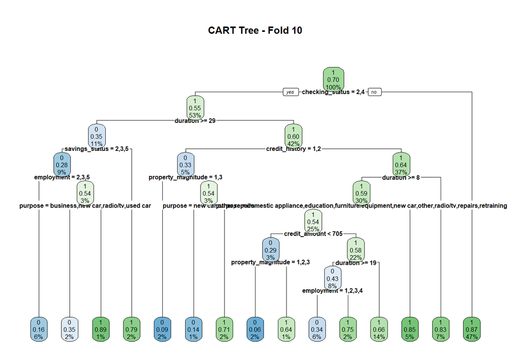

```r
rpart.plot(tree_model, uniform = TRUE,cex = 0.5, main = "CART Tree - Fold 10")
```

## five folds

```r
set.seed(123)
k <- 5

folds <- createFolds(dataset$class, k = k, list = TRUE, returnTrain = FALSE)

# Initialize variables to store metrics
sensitivity_vec <- specificity_vec <- precision_vec <- numeric(k)

for (i in 1:k) {
  test_indices <- unlist(folds[[i]])

  training_set <- dataset[-test_indices, ]
  testing_set <- dataset[test_indices, ]

  tree_model <- rpart(class ~ checking_status + duration + credit_history + purpose + credit_amount + savings_status +
                        employment + installment_commitment + personal_status + other_parties + residence_since +
                        property_magnitude + age + other_payment_plans + housing + existing_credits + job +
                        num_dependents + own_telephone + foreign_worker,
                      data = training_set, method = 'class', parms = list(split = 'gini'))

  predictions <- predict(tree_model, newdata = testing_set, type = 'class')

  confusion_matrix <- table(predictions, testing_set$class)
  accuracy <- sum(diag(confusion_matrix)) / sum(confusion_matrix)
  gini <- 1 - sum((table(predictions, testing_set$class) / length(predictions))^2)  # Corrected this line

  # Store metrics
  sensitivity_vec[i] <- confusionMatrix(predictions, testing_set$class)[["byClass"]]["Sensitivity"]
  specificity_vec[i] <- confusionMatrix(predictions, testing_set$class)[["byClass"]]["Specificity"]
  precision_vec[i] <- confusionMatrix(predictions, testing_set$class)[["byClass"]]["Pos Pred Value"]


}
cat(sprintf("Fold: %d, Accuracy: %.2f%%, Gini Index: %.4f\n", i, accuracy * 100, gini))
```

```
## Fold: 5, Accuracy: 71.36%, Gini Index: 0.5844
```

```r
  print(confusion_matrix)
```

```
##
## predictions   0   1
##           0  23  20
##           1  37 119
```

```r
# Print or use the average values of Sensitivity, Specificity, Precision
cat(sprintf("Average Sensitivity: %.2f%%\n", mean(sensitivity_vec) * 100))
```

```
## Average Sensitivity: 39.80%
```

```r
cat(sprintf("Average Specificity: %.2f%%\n", mean(specificity_vec) * 100))
```

```
## Average Specificity: 87.34%
```

```r
cat(sprintf("Average Precision: %.2f%%\n", mean(precision_vec) * 100))
```

```
## Average Precision: 59.04%
```

fold 5: Accuracy: 71.36%, Gini Index: 0.5844 Average Sensitivity: 39.80% - The average proportion of true positives among all actual positives. Indicates the model’s ability to identify positive instances. Average Specificity: 87.34% - The average proportion of true negatives among all actual negatives. Indicates the model’s ability to identify negative instances. Average Precision: 59.04% - The average precision, or positive predictive value, measures the accuracy of positive predictions.

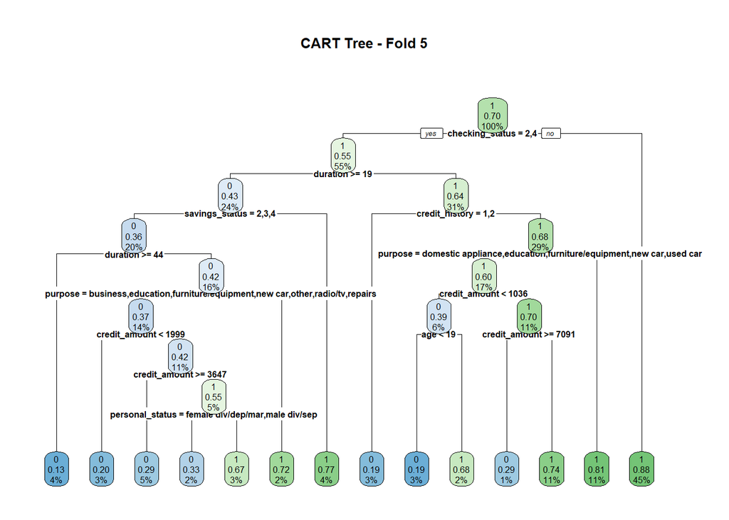

```r
rpart.plot(tree_model, uniform = TRUE,cex = 0.5, main = "CART Tree - Fold 5")
```

For this tree we used Gini Index (CART algorithm) to select the attributes and used5 folds to make the splits . We can see that this tree is less complex compared to the 10 folds tree we discussed earlier since it has less decision and terminal nodes, however it is not significant difference between the two (in terms of complexity) since this tree also has a great number of leaves as well. The ‘checking statues’ attribute is still the root leaf for the tree, splitting our dataset almost in half deciding what class 45% of the customers is from the first split. We can notice that the difference between the trees started to show from the fourth split since the decisions started to be based on different attributes from the previous tree.

## 3 folds

```r
set.seed(123)
k <- 3

folds <- createFolds(dataset$class, k = k, list = TRUE, returnTrain = FALSE)

# Initialize variables to store metrics
sensitivity_vec <- specificity_vec <- precision_vec <- numeric(k)

for (i in 1:k) {
  test_indices <- unlist(folds[[i]])

  training_set <- dataset[-test_indices, ]
  testing_set <- dataset[test_indices, ]

  tree_model <- rpart(class ~ checking_status + duration + credit_history + purpose + credit_amount + savings_status +
                        employment + installment_commitment + personal_status + other_parties + residence_since +
                        property_magnitude + age + other_payment_plans + housing + existing_credits + job +
                        num_dependents + own_telephone + foreign_worker,
                      data = training_set, method = 'class', parms = list(split = 'gini'))

  predictions <- predict(tree_model, newdata = testing_set, type = 'class')

  confusion_matrix <- table(predictions, testing_set$class)
  accuracy <- sum(diag(confusion_matrix)) / sum(confusion_matrix)
  gini <- 1 - sum((table(predictions, testing_set$class) / length(predictions))^2)  # Corrected this line

  # Store metrics
  sensitivity_vec[i] <- confusionMatrix(predictions, testing_set$class)[["byClass"]]["Sensitivity"]
  specificity_vec[i] <- confusionMatrix(predictions, testing_set$class)[["byClass"]]["Specificity"]
  precision_vec[i] <- confusionMatrix(predictions, testing_set$class)[["byClass"]]["Pos Pred Value"]


}
cat(sprintf("Fold: %d, Accuracy: %.2f%%, Gini Index: %.4f\n", i, accuracy * 100, gini))
```

```
## Fold: 3, Accuracy: 71.60%, Gini Index: 0.5844
```

```r
  print(confusion_matrix)
```

```
##
## predictions   0   1
##           0  39  33
##           1  61 198
```

```r
# Print or use the average values of Sensitivity, Specificity, Precision
cat(sprintf("Average Sensitivity: %.2f%%\n", mean(sensitivity_vec) * 100))
```

```
## Average Sensitivity: 42.13%
```

```r
cat(sprintf("Average Specificity: %.2f%%\n", mean(specificity_vec) * 100))
```

```
## Average Specificity: 85.90%
```

```r
cat(sprintf("Average Precision: %.2f%%\n", mean(precision_vec) * 100))
```

```
## Average Precision: 56.95%
```

Fold: 3: Accuracy: 71.60%, Gini Index: 0.5844

Average Sensitivity: This is relatively low at 42.13%. It indicates the proportion of actual positive instances correctly predicted as positive. A higher sensitivity is desirable, especially if identifying positive instances is crucial.

Average Specificity: This is relatively high at 85.90%. It indicates the proportion of actual negative instances correctly predicted as negative. High specificity is generally good, but it might be due to the imbalance in the dataset.

Average Precision: Precision is the proportion of true positive predictions among all positive predictions. The average precision is 56.95%, suggesting that about 57% of the instances predicted as positive are true positives.

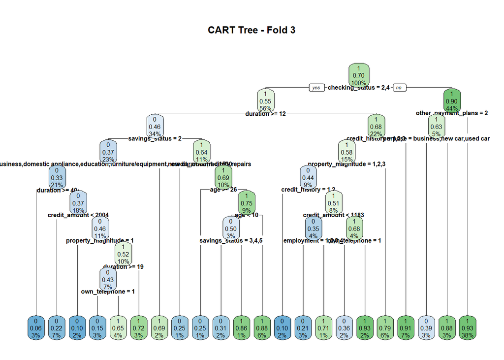

```r
rpart.plot(tree_model, uniform = TRUE,cex = 0.5, main = "CART Tree - Fold 3")
```

For this tree we used Gini Index (CART algorithm) to select the attributes and used3 folds to make the splits . We can say that this tree is most complex out of the 3 trees we made so far. The root is still the ‘checking status’ attribute, it did split the dataset rows almost in half (56% and 44%) but it didn’t decided any class for the customers from the first split like the 2 previous trees. Another indication for its complexity is how much decision and terminal nodes this tree has, with more than 20 terminal nodes we know that this tree is highly affected by outliers or rare cases that it has this much of terminal nodes.

The variation in tree complexity across different folds is noteworthy. For instance, observing that in certain folds the tree becomes notably complex, containing a larger number of decision nodes and terminal leaves, while in other folds, it maintains a comparatively simpler structure. This variance in complexity might reflect the diversity or imbalance within the dataset subsets used for training in each fold. We can say that using 5 folds for this algorithm gave the least complex tree which could indicate that the data using that fold was the most balanced out of the three.

## gain ratio (C4.5 algorithm)

The C5.0 function is using the gain ratio for splitting nodes in the decision tree. The control argument is specifying additional parameters, and CF in this case is controlling the cost factor for misclassification. It doesn’t affect the splitting criterion, which remains gain ratio by default.

## 10 folds

```r
set.seed(123)
myFormula <- class ~ checking_status + duration + credit_history + purpose + credit_amount + savings_status +
  employment + installment_commitment + personal_status + other_parties + residence_since +
  property_magnitude + age + other_payment_plans + housing + existing_credits + job +
  num_dependents + own_telephone + foreign_worker

# Define the number of folds
num_folds <- 10

# Initialize variables to store overall performance metrics
overall_sensitivity <- 0
overall_specificity <- 0
overall_precision <- 0

# Perform cross-validation with C5.0 and pruning
folds <- createFolds(dataset$class, k = num_folds, list = TRUE, returnTrain = FALSE)

for (i in 1:num_folds) {
  # Extract the indices for the current fold
  test_indices <- unlist(folds[[i]])

  # Create training and testing sets
  training_set <- dataset[-test_indices, ]
  testing_set <- dataset[test_indices, ]

  # Train the C5.0 model with pruning
  tree_model <- C5.0(myFormula, data = training_set, control = C5.0Control(CF = 0.01))

  # Make predictions on the testing set
  predictions <- predict(tree_model, newdata = testing_set)

  # Evaluate the model
  confusion_matrix <- table(predictions, testing_set$class)
  accuracy <- sum(diag(confusion_matrix)) / sum(confusion_matrix)

  # Compute Sensitivity, Specificity, Precision using caret's confusionMatrix
  perf_metrics <- confusionMatrix(predictions, testing_set$class)$byClass

  # Aggregate metrics for overall performance
  overall_sensitivity <- overall_sensitivity + perf_metrics["Sensitivity"]
  overall_specificity <- overall_specificity + perf_metrics["Specificity"]
  overall_precision <- overall_precision + perf_metrics["Pos Pred Value"]


}
 cat(sprintf("Fold: %d, Accuracy: %.2f%%\n", i, accuracy * 100))
```

```
## Fold: 10, Accuracy: 68.69%
```

```r
  print(confusion_matrix)
```

```
##
## predictions  0  1
##           0 10 11
##           1 20 58
```

```r
# Calculate average metrics over all folds
avg_sensitivity <- overall_sensitivity / num_folds
avg_specificity <- overall_specificity / num_folds
avg_precision <- overall_precision / num_folds

# Print or use the average values as needed
cat(sprintf("Average Sensitivity: %.2f%%\n", avg_sensitivity * 100))
```

```
## Average Sensitivity: 40.13%
```

```r
cat(sprintf("Average Specificity: %.2f%%\n", avg_specificity * 100))
```

```
## Average Specificity: 86.19%
```

```r
cat(sprintf("Average Precision: %.2f%%\n", avg_precision * 100))
```

```
## Average Precision: 56.80%
```

Fold 10: accuracy:68.69%.

Average Sensitivity: 40.13% measures the proportion of actual positive instances that were correctly identified by the model. In this case, the model, on average, correctly identified only 40.13% of the actual positive instances.

Average Specificity: 86.19% Specificity (True Negative Rate) measures the proportion of actual negative instances that were correctly identified by the model. The model, on average, correctly identified 86.19% of the actual negative instances.

Average Precision: 56.80% Precision (Positive Predictive Value) measures the proportion of positive instances among the instances predicted as positive by the model. On average, 56.80% of the instances predicted as positive by the model were actually positive.

[figure not shown]

```r
plot(tree_model, uniform = TRUE, cex = 0.7,main = "C4.5 Tree - Fold 10")
```

For this tree we used Gain ratio (C4.5) to select the attributes and used 10 folds to make the splits . We can see that the ‘checking status’ is the root node that start the splitting (it also split the data almost in half) deciding the class label for 418 customers from the first split. We are dealing with 10 terminal nodes which means that this tree is less complicated than all the Gini index trees (that does not mean that the results will be better regarding the accuracy and other metrics). We can see the presence of new attributes that was not in the Gini index trees which highlights the difference between Gain Ratio and Gini Index, The Gini index focuses on impurity reduction, favors attributes that most effectively separate classes, while Gain Ratio is biased towards attributes with many values by adjusting the information gain

## 5 folds

```r
set.seed(123)
myFormula <- class ~ checking_status + duration + credit_history + purpose + credit_amount + savings_status +
  employment + installment_commitment + personal_status + other_parties + residence_since +
  property_magnitude + age + other_payment_plans + housing + existing_credits + job +
  num_dependents + own_telephone + foreign_worker
# Define the number of folds
num_folds <- 5

# Initialize variables to store overall performance metrics
overall_sensitivity <- 0
overall_specificity <- 0
overall_precision <- 0

# Perform cross-validation with C5.0 and pruning
folds <- createFolds(dataset$class, k = num_folds, list = TRUE, returnTrain = FALSE)

for (i in 1:num_folds) {
  # Extract the indices for the current fold
  test_indices <- unlist(folds[[i]])

  # Create training and testing sets
  training_set <- dataset[-test_indices, ]
  testing_set <- dataset[test_indices, ]

  # Train the C5.0 model with pruning
  tree_model <- C5.0(myFormula, data = training_set, control = C5.0Control(CF = 0.01))

  # Make predictions on the testing set
  predictions <- predict(tree_model, newdata = testing_set)

  # Evaluate the model
  confusion_matrix <- table(predictions, testing_set$class)
  accuracy <- sum(diag(confusion_matrix)) / sum(confusion_matrix)

  # Compute Sensitivity, Specificity, Precision using caret's confusionMatrix
  perf_metrics <- confusionMatrix(predictions, testing_set$class)$byClass

  # Aggregate metrics for overall performance
  overall_sensitivity <- overall_sensitivity + perf_metrics["Sensitivity"]
  overall_specificity <- overall_specificity + perf_metrics["Specificity"]
  overall_precision <- overall_precision + perf_metrics["Pos Pred Value"]


}
 cat(sprintf("Fold: %d, Accuracy: %.2f%%\n", i, accuracy * 100))
```

```
## Fold: 5, Accuracy: 69.35%
```

```r
  print(confusion_matrix)
```

```
##
## predictions   0   1
##           0  21  22
##           1  39 117
```

```r
# Calculate average metrics over all folds
avg_sensitivity <- overall_sensitivity / num_folds
avg_specificity <- overall_specificity / num_folds
avg_precision <- overall_precision / num_folds

# Print or use the average values as needed
cat(sprintf("Average Sensitivity: %.2f%%\n", avg_sensitivity * 100))
```

```
## Average Sensitivity: 38.49%
```

```r
cat(sprintf("Average Specificity: %.2f%%\n", avg_specificity * 100))
```

```
## Average Specificity: 85.18%
```

```r
cat(sprintf("Average Precision: %.2f%%\n", avg_precision * 100))
```

```
## Average Precision: 52.27%
```

fold5: Accuracy: 69.35%

Average Sensitivity: 38.49%: Sensitivity (also called recall or true positive rate) is the ability of the model to correctly identify positive instances. In this case, the average sensitivity is relatively low at 38.49%, suggesting that the model has difficulty correctly identifying positive cases.

Average Specificity: 85.18%: Specificity is the ability of the model to correctly identify negative instances. The average specificity is relatively high at 85.18%, indicating that the model is performing well in identifying negative cases.

Average Precision: 52.27%: Precision is the ratio of correctly predicted positive observations to the total predicted positives. An average precision of 52.27% suggests that, on average, around half of the instances predicted as positive by the model are true positives.

[figure not shown]

```r
plot(tree_model, uniform = TRUE, main = "C4.5 Tree - Fold 5")
```

For this tree we used Gain ratio (C4.5) to select the attributes and used 5 folds to make the splits . Right from the start we can see that this tree is more complex that the 10 folds tree for the same algorithm, the root node is still the same but it decided the class for less customers in the first split, there is more decision nodes and the terminal nodes (15+) represent very specific cases of customers which can indicate the possibility of overfitting. Comparing this tree with the 10 fold tree , we can say that there might be a possibility of that the 5 folds doesn’t generalize (work on new/unseen data) very well.

## 3 folds

```r
set.seed(123)
myFormula <- class ~ checking_status + duration + credit_history + purpose + credit_amount + savings_status +
  employment + installment_commitment + personal_status + other_parties + residence_since +
  property_magnitude + age + other_payment_plans + housing + existing_credits + job +
  num_dependents + own_telephone + foreign_worker
# Define the number of folds
num_folds <- 3

# Initialize variables to store overall performance metrics
overall_sensitivity <- 0
overall_specificity <- 0

# Perform cross-validation with C5.0 and pruning
folds <- createFolds(dataset$class, k = num_folds, list = TRUE, returnTrain = FALSE)

for (i in 1:num_folds) {
  # Extract the indices for the current fold
  test_indices <- unlist(folds[[i]])

  # Create training and testing sets
  training_set <- dataset[-test_indices, ]
  testing_set <- dataset[test_indices, ]

  # Train the C5.0 model with pruning
  tree_model <- C5.0(myFormula, data = training_set, control = C5.0Control(CF = 0.01))

  # Make predictions on the testing set
  predictions <- predict(tree_model, newdata = testing_set)

  # Evaluate the model
  confusion_matrix <- table(predictions, testing_set$class)
  accuracy <- sum(diag(confusion_matrix)) / sum(confusion_matrix)

  # Compute Sensitivity, Specificity, Precision using caret's confusionMatrix
  perf_metrics <- confusionMatrix(predictions, testing_set$class)$byClass

  # Aggregate metrics for overall performance
  overall_sensitivity <- overall_sensitivity + perf_metrics["Sensitivity"]
  overall_specificity <- overall_specificity + perf_metrics["Specificity"]


}
 cat(sprintf("Fold: %d, Accuracy: %.2f%%\n", i, accuracy * 100))
```

```
## Fold: 3, Accuracy: 71.60%
```

```r
  print(confusion_matrix)
```

```
##
## predictions   0   1
##           0  37  31
##           1  63 200
```

```r
# Calculate average metrics over all folds
avg_sensitivity <- overall_sensitivity / num_folds
avg_specificity <- overall_specificity / num_folds

# Print or use the average values as needed
cat(sprintf("Average Sensitivity: %.2f%%\n", avg_sensitivity * 100))
```

```
## Average Sensitivity: 17.67%
```

```r
cat(sprintf("Average Specificity: %.2f%%\n", avg_specificity * 100))
```

```
## Average Specificity: 93.95%
```

Average Sensitivity: 17.67% : The average proportion of true positives among all actual positives. It suggests that the model, on average, correctly identified only 17.67% of the actual positive instances.

Average Specificity: 93.95%: The average proportion of true negatives among all actual negatives. It indicates that the model, on average, correctly identified 93.95% of the actual negative instances. This is relatively high and suggests good performance in avoiding false alarms for negative instances.

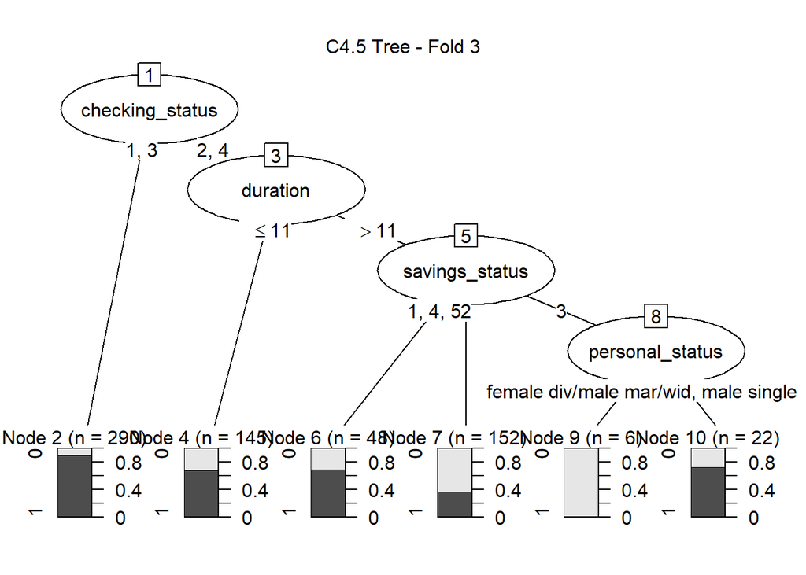

```r
plot(tree_model, uniform = TRUE, main = "C4.5 Tree - Fold 3")
```

For this tree we used Gain ratio (C4.5) to select the attributes and used 3 folds to make the splits . Out of the 3 trees that used the Gain Ratio algorithm, this one performed the best regarding complexity, with only 4 decision nodes and 6 terminal nodes . A simpler tree often suggests a higher likelihood of generalizing well to new, unseen data. The small number of decision nodes could imply that only this subset of features significantly influences the target variable in this specific fold. It might be interesting to explore which attributes are chosen as decision nodesin this tree.

Since the 3 folds gave the simplest tree, it might be easier for people to use this model because of its ease in interpretably.